# Prática 8

### Daniel Freitas Martins - 2304

```python
import numpy as np
import pandas as pd
import scipy.stats as stats
import matplotlib.pyplot as plt
import sklearn
import seaborn as sns
from sklearn.linear_model import LinearRegression
```

## 1) Utilizar o conjunto de dados weatherHistory.csv, que contém o histórico de variáveis relacionadas ao clima da cidade de Szede, Hungria, entre 2006 e 2016.

### a) Primeiramente, faça uma análise exploratória dos dados, entendendo as variáveis e suas características. Crie gráficos par-a-par das variáveis para tentar identificar possíveis relações lineares entre elas;

```python
df = pd.read_csv('weatherHistory.csv', header=0)
print(df.columns)
df.head(3)
```

```
Index(['Formatted Date', 'Summary', 'Precip Type', 'Temperature (C)',
       'Apparent Temperature (C)', 'Humidity', 'Wind Speed (km/h)',
       'Wind Bearing (degrees)', 'Visibility (km)', 'Loud Cover',
       'Pressure (millibars)', 'Daily Summary'],
      dtype='object')
```

|  | Formatted Date | Summary | Precip Type | Temperature (C) | Apparent Temperature (C) | Humidity | Wind Speed (km/h) | Wind Bearing (degrees) | Visibility (km) | Loud Cover | Pressure (millibars) | Daily Summary |
| --- | --- | --- | --- | --- | --- | --- | --- | --- | --- | --- | --- | --- |
| 0 | 2006-04-01 00:00:00.000 +0200 | Partly Cloudy | rain | 9.472222 | 7.388889 | 0.89 | 14.1197 | 251.0 | 15.8263 | 0.0 | 1015.13 | Partly cloudy throughout the day. |
| 1 | 2006-04-01 01:00:00.000 +0200 | Partly Cloudy | rain | 9.355556 | 7.227778 | 0.86 | 14.2646 | 259.0 | 15.8263 | 0.0 | 1015.63 | Partly cloudy throughout the day. |
| 2 | 2006-04-01 02:00:00.000 +0200 | Mostly Cloudy | rain | 9.377778 | 9.377778 | 0.89 | 3.9284 | 204.0 | 14.9569 | 0.0 | 1015.94 | Partly cloudy throughout the day. |

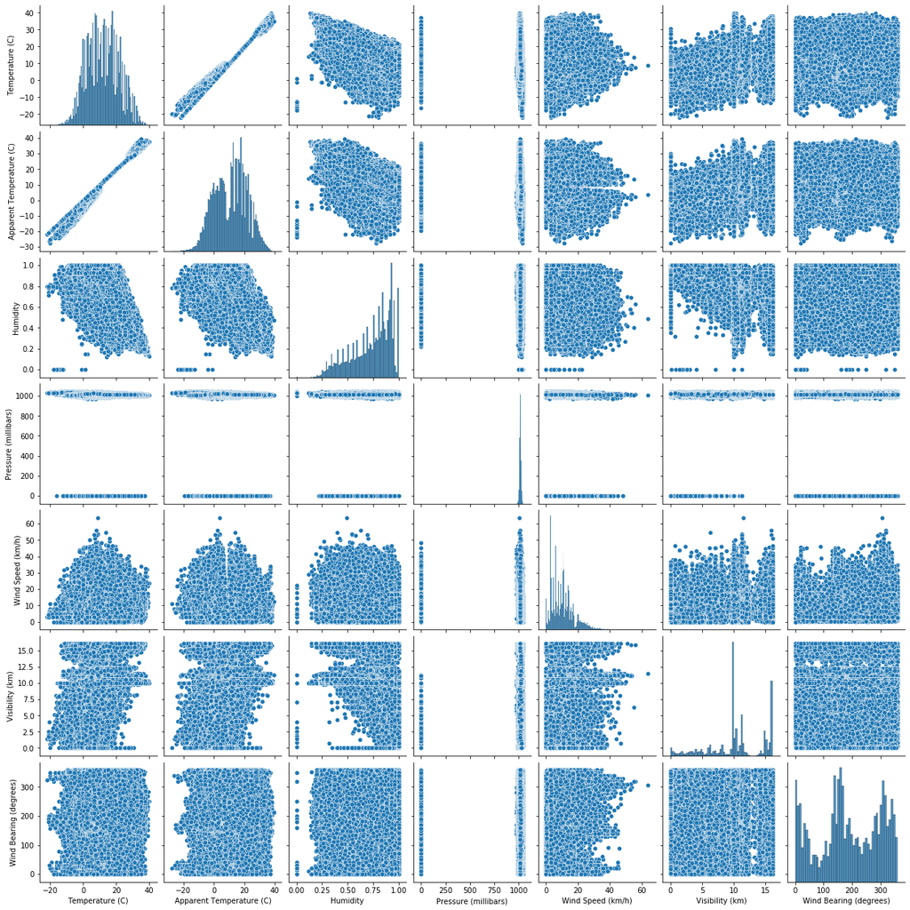

```python
cols = ['Temperature (C)', 'Apparent Temperature (C)', 'Humidity', 'Pressure (millibars)',
        'Wind Speed (km/h)', 'Visibility (km)', 'Wind Bearing (degrees)']
sns.pairplot(df[cols])
```

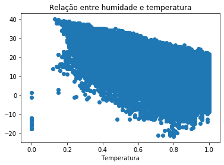

```python
plt.scatter(df['Humidity'], df['Temperature (C)'])
plt.xlabel('Humidade')
plt.xlabel('Temperatura')
plt.title('Relação entre humidade e temperatura')
plt.show()
```

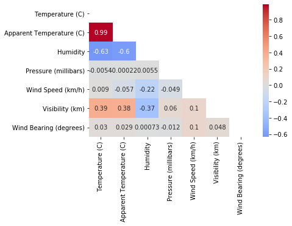

```python
var_corr = df[cols].corr()
matrix = np.triu(df[cols].corr())
sns.heatmap(var_corr, xticklabels=var_corr.columns, yticklabels=var_corr.columns,
           annot=True, center=0, cmap='coolwarm', mask=matrix)
```

### b) Qual a equação linear e o coeficiente de determinação que representa a temperatura em termos da umidade?

```python
def calcLinearRegression(x, y):
    lm = LinearRegression()
    lm.fit(x, y)
    print('Coeficiente estimado:', lm.coef_)
    print('Valor de b (lm.intercept_): ', lm.intercept_)
    print('R2 (score):', lm.score(x, y))
    print('1 - R2 (score):', 1 - lm.score(x, y))
```

```python
x = df[['Humidity']]
y = df['Temperature (C)']
calcLinearRegression(x, y)
```

```
Coeficiente estimado: [-30.89438376]
Valor de b (lm.intercept_):  34.636929126889484
R2 (score): 0.3997459740945123
1 - R2 (score): 0.6002540259054877
```

A equação linear é: T = -30.89438376*H + 34.636929126889484 onde T é a temperatura e H é a humidade.

O coeficiente de determinação é 0.3997459740945123

Podemos inferir que sempre que a humidade aumenta, a temperatura decresce em 30.89 unidades.  
Cerca de 60% da variação da temperatura não é explicada pela humidade.

### c) Qual a equação linear e o coeficiente de determinação que representa a temperatura em termos da umidade e velocidade do vento?

```python
x = df[['Humidity', 'Wind Speed (km/h)']]
y = df['Temperature (C)']
calcLinearRegression(x, y)
```

```
Coeficiente estimado: [-32.43736179  -0.19393433]
Valor de b (lm.intercept_):  37.86741638397869
R2 (score): 0.41845342760046933
1 - R2 (score): 0.5815465723995307
```

A equação linear é: T = -32.43736179*H -0.19393433*W + 37.86741638397869 onde T é a temperatura, H é a humidade e W é a velocidade do vento.

O coeficiente de determinação é 0.41845342760046933

Podemos inferir que sempre que a humidade e a velocidade do vento aumentam, a temperatura decresce em 32.44 unidades com relação à humidade e decresce 0.19 unidades em relação à velocidade do vento.  
Cerca de 58% da variação da temperatura não é explicada pela humidade e velocidade do vento.

### d) Qual a equação linear e o coeficiente de determinação que representa a temperatura aparente em termos da temperatura, da velocidade do vento e da umidade?

```python
x = df[['Temperature (C)', 'Humidity', 'Wind Speed (km/h)']]
y = df['Apparent Temperature (C)']
calcLinearRegression(x, y)
```

```
Coeficiente estimado: [ 1.12592366  1.05544552 -0.09486983]
Valor de b (lm.intercept_):  -2.33029840907785
R2 (score): 0.989812786297048
1 - R2 (score): 0.010187213702951947
```

A equação linear é: A = 1.12592366*T + 1.05544552*H - 0.09486983*W - 2.33029840907785 onde A é a temperatura aparente, T é a temperatura, H é a humidade e W é a velocidade do vento.

O coeficiente de determinação é 0.989812786297048

Podemos inferir que sempre que a temperatura, a humidade e a velocidade do vento aumentam, a temperatura aparente aumenta em 1.13 unidades com relação à temperatura, aumenta em 1.06 unidades com relação à humidade e decresce 0.095 unidades em relação à velocidade do vento.  
Cerca de 1% da variação da temperatura aparente não é explicada pela temperatura, humidade e velocidade do vento.

### e) Quais variáveis do dataset você indica para serem utilizadas para prever a umidade? Explique sua resposta.

```python
x = df[['Temperature (C)']]
y = df['Humidity']
calcLinearRegression(x, y)
```

```
Coeficiente estimado: [-0.01293911]
Valor de b (lm.intercept_):  0.8892972609553129
R2 (score): 0.3997459740945123
1 - R2 (score): 0.6002540259054877
```

```python
x = df[['Apparent Temperature (C)']]
y = df['Humidity']
calcLinearRegression(x, y)
```

```
Coeficiente estimado: [-0.0110113]
Valor de b (lm.intercept_):  0.85442695318432
R2 (score): 0.363091804706307
1 - R2 (score): 0.636908195293693
```

```python
x = df[['Temperature (C)', 'Apparent Temperature (C)', 'Wind Speed (km/h)', 'Visibility (km)']]
y = df['Humidity']
calcLinearRegression(x, y)
```

```
Coeficiente estimado: [-0.032367    0.01834417 -0.00401935 -0.00544252]
Valor de b (lm.intercept_):  1.0217647227462423
R2 (score): 0.470138020984072
1 - R2 (score): 0.529861979015928
```

Pelos valores de correlação de Pearson, podemos notar que as variáveis com correlações mais altas em relação à humidade são Temperature e Apparente Temperature. No entanto, temos também que outras como Wind Speed e Visibility possuem valores que podem auxiliar para inferências dos valores de humidade. Sendo assim, indicaria as variáveis:

- Temperature (C)
- Apparent Temperature (C)

E, em conjunto, com melhores resultados (coeficiente de determinação igual a 47%):

- Temperature (C), Apparent Temperature (C), Wind Speed (km/h), Visibility (km)